# Sixteen Years of 311: How Resolution Odds Changed Across Administrations

Recorded resolution-time probabilities for NYC 311 service requests, 2010–2026, compared across mayoral administrations — citywide, by complaint type, and within individual census tracts.

Published

September 19, 2026

**NoteHow to read this document**

Plain-language takeaways open each section; the code that produced every number and figure is folded beneath it (click “Code”). To reproduce: run the pipeline in `pipeline/` (`fetch_311.py`, `fetch_311_history.py`, `prepare.py`, `prepare_hist.py`), then render this file with `quarto render docs/historical_analysis.qmd`.

## Summary

This analysis asks how the *recorded* probability that a 311 request gets resolved — within 3 hours, within a day, within a week — has moved since 2010, and whether different mayoral administrations are associated with different odds **in the same census tract**. Three design choices matter throughout:

1. **Within-type comparisons.** What New Yorkers report changed enormously (the 311 app made noise complaints explode), and complaint types resolve at wildly different speeds. Comparing administrations on the all-complaints average mostly measures this composition shift, so every comparison here is within a complaint type.
2. **Recorded, not necessarily real.** A “resolution” is the city closing the ticket. Closure practices (batch purges, auto-close policies) changed across eras; we flag and quantify these artifacts rather than pretend they don’t exist.
3. **COVID is its own era.** March 2020 – December 2021 is a structural break and is never averaged into an administration’s record.

**Setup: load 16 years of cleaned requests, define eras**

```python
import glob, json, os, sys
import numpy as np
import pandas as pd
import matplotlib
import matplotlib.pyplot as plt

ROOT = ".." if os.path.basename(os.getcwd()) == "docs" else "."
sys.path.insert(0, os.path.join(ROOT, "pipeline"))
import model as M

ERAS = [
    ("bloomberg", "Bloomberg (final term)", "2010-01-01", "2014-01-01"),
    ("deblasio",  "de Blasio (pre-COVID)",  "2014-01-01", "2020-03-01"),
    ("covid",     "COVID emergency",        "2020-03-01", "2022-01-01"),
    ("adams",     "Adams",                  "2022-01-01", "2026-01-01"),
    ("current",   "Mamdani (2026)",         "2026-01-01", "2027-01-01"),
]
ERA_LABEL = {k: lb for k, lb, *_ in ERAS}

# conservative 1:1 taxonomy renames across the study period
RENAMES = {"HEATING": "HEAT/HOT WATER", "PAINT - PLASTER": "PAINT/PLASTER",
           "NONCONST": "UNSANITARY CONDITION", "Sewer Maintenance": "Sewer"}

parts = sorted(glob.glob(os.path.join(ROOT, "data", "prepared_hist", "year=*.parquet")))
df = pd.concat([pd.read_parquet(p) for p in parts]
               + [pd.read_parquet(os.path.join(ROOT, "data", "prepared.parquet"))
                  .query("created_date >= '2025-01-01'")],   # prepared_hist already covers <=2024
               ignore_index=True)
df["created_date"] = pd.to_datetime(df["created_date"])
for c in ["geoid", "nta", "boro", "complaint_type"]:
    df[c] = df[c].astype(str)
df.loc[df["geoid"].isin(["nan", "None", "<NA>"]), "geoid"] = np.nan
df["complaint_type"] = df["complaint_type"].replace(RENAMES)
df["era"] = pd.cut(df["created_date"],
                   bins=[pd.Timestamp(s) for _, _, s, _ in ERAS] + [pd.Timestamp(ERAS[-1][3])],
                   labels=[k for k, *_ in ERAS], right=False)
df = df[df["era"].notna()]
df["year"] = df["created_date"].dt.year
N_TOTAL = len(df)
SPAN = (df["created_date"].min().date(), df["created_date"].max().date())
era_keys = [k for k, *_ in ERAS if (df["era"] == k).any()]   # eras with data present

# dark theme to match the map app
C = {"bg": "#0B0E14", "text": "#F2F4F8", "sub": "#9AA3B5", "line": "#2A3244",
     "accent": "#FFB84D"}
plt.rcParams.update({
    "figure.facecolor": C["bg"], "axes.facecolor": C["bg"], "savefig.facecolor": C["bg"],
    "axes.edgecolor": C["line"], "axes.labelcolor": C["sub"], "text.color": C["text"],
    "xtick.color": C["sub"], "ytick.color": C["sub"], "axes.grid": True,
    "grid.color": C["line"], "grid.linewidth": 0.5, "font.size": 11})
```

The analysis covers **40,670,321** cleaned, matured service requests created between 2010-01-01 and 2026-08-18, all passed through the identical hygiene rules as the live map (de-duplication, double-submission collapse, negative/zero-duration removal, batch-closure flagging, point-in-polygon assignment to 2020 census tracts — see `docs/METHODS.md`).

## The data changed as much as the city did

Before comparing administrations, look at what the instrument itself was doing. Request volume roughly doubled; the complaint mix transformed; geocoding quality improved; and the share of requests never administratively closed varies by era. Every one of these can masquerade as a “service change.”

**Era context table: volume, composition, artifact rates**

```python
rows = []
for key, label, s, e in ERAS:
    sub = df[df["era"] == key]
    if len(sub) == 0:
        continue
    yrs = max((pd.Timestamp(e) - pd.Timestamp(s)).days / 365.25, 5 / 12)
    top3 = sub["complaint_type"].value_counts(normalize=True).head(3)
    rows.append({
        "era": label,
        "requests/yr (M)": round(len(sub) / yrs / 1e6, 2),
        "share never closed": f'{(sub["bin"].eq(M.K - 1) & 1).mean():.1%}',
        "batch-closure flagged": f'{sub["batch_closed"].mean():.1%}',
        "tract-geocoded": f'{sub["geoid"].notna().mean():.1%}',
        "top complaint (share)": f"{top3.index[0].title()} ({top3.iloc[0]:.0%})",
    })
pd.DataFrame(rows).set_index("era")
```

| era | requests/yr (M) | share never closed | batch-closure flagged | tract-geocoded | top complaint (share) |
| --- | --- | --- | --- | --- | --- |
| Bloomberg (final term) | 1.63 | 12.6% | 28.3% | 88.5% | Heat/Hot Water (9%) |
| de Blasio (pre-COVID) | 2.22 | 10.6% | 12.2% | 93.8% | Noise - Residential (10%) |
| COVID emergency | 2.93 | 8.7% | 13.3% | 98.8% | Noise - Residential (12%) |
| Adams | 3.17 | 9.9% | 1.2% | 98.6% | Illegal Parking (15%) |
| Mamdani (2026) | 2.43 | 9.9% | 2.7% | 97.9% | Illegal Parking (16%) |

**WarningWhat this table means for interpretation**

The comparisons below are of **recorded closures under each era’s record-keeping practices**. Where an era’s batch-closure or never-closed rates stand out, treat its differences as partly administrative. Tract geocoding also improves over time; rows without coordinates still inform borough and citywide estimates but not tract-level ones.

**Select complaint types comparable across all five eras**

```python
MIN_PER_ERA = 15_000
vol = df.groupby(["complaint_type", "era"], observed=True).size().unstack("era", fill_value=0)
stable = vol[(vol >= MIN_PER_ERA).all(axis=1)].sort_values("adams", ascending=False)
TYPES = stable.index.tolist()
```

Cross-era comparisons use the **27** complaint types that appear with meaningful volume (≥15,000 requests) in *every* era, after normalizing known renames (e.g., pre-2014 “HEATING” is today’s “Heat/Hot Water”): Illegal Parking, Noise - Residential, Heat/Hot Water, Blocked Driveway, Noise - Street/Sidewalk, Unsanitary Condition, Street Condition, Noise - Commercial, Plumbing, Water System, Noise, Paint/Plaster, Noise - Vehicle, Derelict Vehicles, Traffic Signal Condition, General Construction/Plumbing, Damaged Tree, Electric, Sewer, Street Light Condition, Sidewalk Condition, Maintenance Or Facility, Non-Emergency Police Matter, Appliance, Overgrown Tree/Branches, Elevator, Building/Use.

## The long view: same-day resolution, 2010–2026

**Annual P(resolved ≤ 24h) by complaint type**

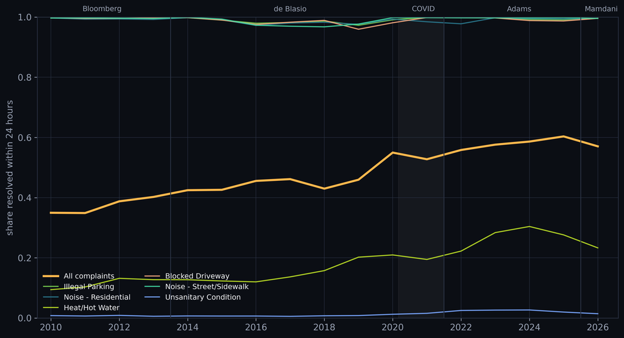

```python
fig, ax = plt.subplots(figsize=(11, 6))
palette = ["#FFB84D", "#7AD151", "#2A788E", "#BDDF26", "#F5A97F", "#43D9A3",
           "#7AA7FF", "#D183C9"]
sel = ["ALL"] + TYPES[:6]
for i, t in enumerate(sel):
    sub = df if t == "ALL" else df[df["complaint_type"] == t]
    ann = sub.groupby("year")["bin"].apply(lambda s: (s <= 1).mean())
    ax.plot(ann.index, ann.values, color=palette[i % len(palette)],
            lw=2.6 if t == "ALL" else 1.4, alpha=1 if t == "ALL" else .9,
            label="All complaints" if t == "ALL" else t.title())
for x in [2014, 2022, 2026]:
    ax.axvline(x - .5, color=C["line"], lw=1)
ax.axvspan(2020.17, 2022 - .5, color="#FFFFFF", alpha=.045)
for x, name in [(2011.5, "Bloomberg"), (2017, "de Blasio"), (2020.9, "COVID"),
                (2023.7, "Adams"), (2026.1, "Mamdani")]:
    ax.text(x, 1.02, name, transform=ax.get_xaxis_transform(), ha="center",
            fontsize=9, color=C["sub"])
ax.set_ylim(0, 1); ax.set_xlim(2009.6, 2026.6)
ax.set_ylabel("share resolved within 24 hours")
ax.legend(loc="lower left", frameon=False, fontsize=9, ncols=2)
plt.tight_layout(); plt.show()
```

**Composition-adjusted citywide same-day rate**

```python
ctype_all = df["complaint_type"].where(df["complaint_type"].isin(TYPES), "Other")
mix = ctype_all.value_counts(normalize=True)                     # fixed all-era mix
era_type_p24 = (df.assign(ct=ctype_all).groupby(["era", "ct"], observed=True)["bin"]
                  .apply(lambda s: (s <= 1).mean()).unstack("ct"))
raw_all = df.groupby("era", observed=True)["bin"].apply(lambda s: (s <= 1).mean())
adj_all = (era_type_p24 * mix).sum(axis=1)
adj = pd.DataFrame({"raw P(≤24h)": raw_all.round(3), "mix-adjusted": adj_all.round(3)})
adj.index = [ERA_LABEL[k] for k in adj.index]
adj
```

|  | raw P(≤24h) | mix-adjusted |
| --- | --- | --- |
| Bloomberg (final term) | 0.371 | 0.482 |
| de Blasio (pre-COVID) | 0.445 | 0.475 |
| COVID emergency | 0.541 | 0.492 |
| Adams | 0.582 | 0.528 |
| Mamdani (2026) | 0.570 | 0.524 |

The gap between the raw and mix-adjusted columns is the composition effect: how much of each era’s apparent speed comes from *what was reported* rather than *how fast it was handled*. Interpretation in the prose below uses the adjusted view.

## Era × complaint type

**Era × type heatmap**

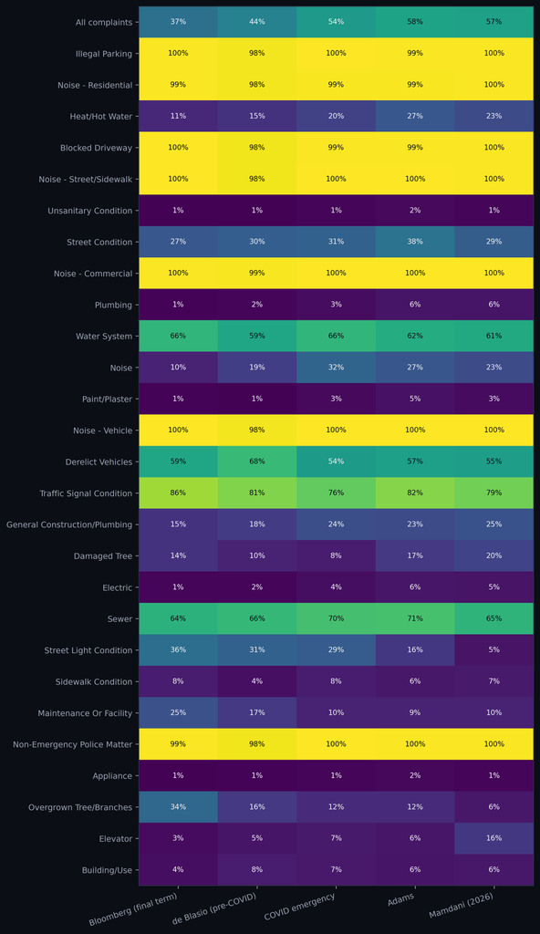

Figure 2: Recorded share of requests resolved within 24 hours, by era and complaint type.

```python
tt = ["ALL"] + TYPES
mat = np.full((len(tt), len(era_keys)), np.nan)
for j, k in enumerate(era_keys):
    sub = df[df["era"] == k]
    mat[0, j] = (sub["bin"] <= 1).mean()
    for i, t in enumerate(TYPES, start=1):
        s2 = sub.loc[sub["complaint_type"] == t, "bin"]
        if len(s2):
            mat[i, j] = (s2 <= 1).mean()
fig, ax = plt.subplots(figsize=(8.5, .45 * len(tt) + 2))
ax.imshow(mat, cmap="viridis", vmin=0, vmax=1, aspect="auto")
ax.set_xticks(range(len(era_keys)), [ERA_LABEL[k] for k in era_keys],
              rotation=18, ha="right", fontsize=9)
ax.set_yticks(range(len(tt)),
              ["All complaints" if t == "ALL" else t.title() for t in tt], fontsize=9)
for i in range(len(tt)):
    for j in range(len(era_keys)):
        if not np.isnan(mat[i, j]):
            ax.text(j, i, f"{mat[i,j]:.0%}", ha="center", va="center", fontsize=8,
                    color="#0B0E14" if mat[i, j] > .55 else "#F2F4F8")
ax.grid(False); plt.tight_layout(); plt.show()
```

## Within the same tract: administration deltas

The citywide picture can hide local reversals. Here we fit the **same hierarchical Bayesian model that powers the live map** (tract → neighborhood → borough → city, per complaint type; concentrations by marginal-likelihood MLE) separately to each era’s data, then difference the posterior same-day probabilities tract by tract. Only tracts with at least 30 requests of that type in *both* eras are compared, so the deltas reflect local evidence rather than shared priors.

**Fit the hierarchical model per era; compute tract-level deltas**

```python
geo = M.GeoIndex(json.load(open(os.path.join(ROOT, "data", "geo_lookup.json"))))
MIN_TRACT_N = 30
tix = {t: i for i, t in enumerate(TYPES + ["Other"])}

fits, counts = {}, {}
for key in era_keys:
    sub = df[df["era"] == key].copy()
    sub["ctype"] = M.collapse_types(sub["complaint_type"], TYPES)
    fits[key] = M.fit(sub, geo, TYPES + ["Other"], M.Config("era", half_life_days=None, cutwise=True),
                      sub["created_date"].max())
    s2 = sub[sub["geoid"].notna()]
    counts[key] = s2.groupby([s2["geoid"], s2["ctype"]], observed=True).size()

def p24_and_var(fm):
    # mean and variance of P(resolved within 24 hours) from the shipped per-threshold model
    return fm.cum_mean()[..., 1], fm.cum_variance()[..., 1]

def tract_deltas(a_key, b_key):
    ma, va = p24_and_var(fits[a_key]); mb, vb = p24_and_var(fits[b_key])
    out = {}
    for t in TYPES:
        ti = tix[t]; recs = []
        for g, gi in geo.tract_ix.items():
            if counts[a_key].get((g, t), 0) < MIN_TRACT_N: continue
            if counts[b_key].get((g, t), 0) < MIN_TRACT_N: continue
            d = ma[gi, ti] - mb[gi, ti]
            se = np.sqrt(va[gi, ti] + vb[gi, ti])
            recs.append((g, d, se))
        if len(recs) >= 25:
            dd = np.array([r[1] for r in recs])
            out[t] = {"recs": recs, "n": len(recs),
                      "med": np.median(dd),
                      "q10": np.percentile(dd, 10), "q90": np.percentile(dd, 90),
                      "up": np.mean([d - 1.645 * s > 0 for _, d, s in recs]),
                      "dn": np.mean([d + 1.645 * s < 0 for _, d, s in recs])}
    return out

D_ad = tract_deltas("adams", "deblasio")
D_ca = tract_deltas("current", "adams")

def delta_table(D):
    return pd.DataFrame({
        "tracts compared": {t.title(): v["n"] for t, v in D.items()},
        "median Δ (pts)": {t.title(): round(100 * v["med"], 1) for t, v in D.items()},
        "10th–90th pct": {t.title(): f'{100*v["q10"]:+.0f} … {100*v["q90"]:+.0f}'
                          for t, v in D.items()},
        "share sig. faster": {t.title(): f'{v["up"]:.0%}' for t, v in D.items()},
        "share sig. slower": {t.title(): f'{v["dn"]:.0%}' for t, v in D.items()},
    }).sort_values("median Δ (pts)", ascending=False)
```

**Delta table: Adams vs de Blasio**

```python
delta_table(D_ad)
```

Table 1: Adams vs de Blasio (pre-COVID): change in P(resolved ≤ 24h) within the same tract, by complaint type. “Sig.” = the tract’s 90% interval on the change excludes zero.

|  | tracts compared | median Δ (pts) | 10th–90th pct | share sig. faster | share sig. slower |
| --- | --- | --- | --- | --- | --- |
| Heat/Hot Water | 1883 | 10.9 | +4 … +19 | 87% | 1% |
| Street Condition | 1987 | 7.4 | -2 … +19 | 51% | 2% |
| Damaged Tree | 1256 | 6.0 | -0 … +14 | 55% | 0% |
| Noise | 1475 | 5.8 | -4 … +16 | 42% | 4% |
| Sewer | 1419 | 4.9 | -9 … +18 | 35% | 10% |
| Electric | 884 | 4.2 | +2 … +7 | 77% | 0% |
| Paint/Plaster | 1193 | 4.0 | +2 … +6 | 98% | 0% |
| Plumbing | 1290 | 3.5 | +1 … +7 | 71% | 0% |
| Sidewalk Condition | 1283 | 2.4 | -0 … +5 | 35% | 2% |
| Water System | 2001 | 2.2 | -11 … +18 | 32% | 16% |
| Unsanitary Condition | 1610 | 1.7 | +0 … +3 | 75% | 0% |
| Traffic Signal Condition | 1168 | 1.2 | -5 … +7 | 11% | 6% |
| Appliance | 593 | 1.0 | +0 … +2 | 31% | 0% |
| Elevator | 527 | 0.8 | -3 … +6 | 17% | 6% |
| General Construction/Plumbing | 1507 | 0.5 | -7 … +12 | 19% | 10% |
| Illegal Parking | 2254 | 0.5 | -1 … +5 | 52% | 11% |
| Noise - Street/Sidewalk | 1517 | 0.4 | -0 … +4 | 33% | 3% |
| Blocked Driveway | 2035 | 0.4 | -1 … +4 | 55% | 13% |
| Non-Emergency Police Matter | 237 | 0.4 | -1 … +4 | 27% | 6% |
| Noise - Vehicle | 1075 | 0.3 | -0 … +4 | 24% | 2% |
| Noise - Residential | 2190 | 0.2 | -1 … +3 | 38% | 8% |
| Noise - Commercial | 892 | 0.2 | -0 … +2 | 25% | 2% |
| Overgrown Tree/Branches | 906 | -1.2 | -16 … +3 | 8% | 35% |
| Maintenance Or Facility | 176 | -1.3 | -25 … +11 | 28% | 35% |
| Building/Use | 866 | -1.4 | -6 … +3 | 3% | 18% |
| Derelict Vehicles | 1099 | -10.9 | -36 … +7 | 10% | 60% |
| Street Light Condition | 1022 | -22.0 | -34 … +1 | 2% | 75% |

**Choropleth of tract deltas**

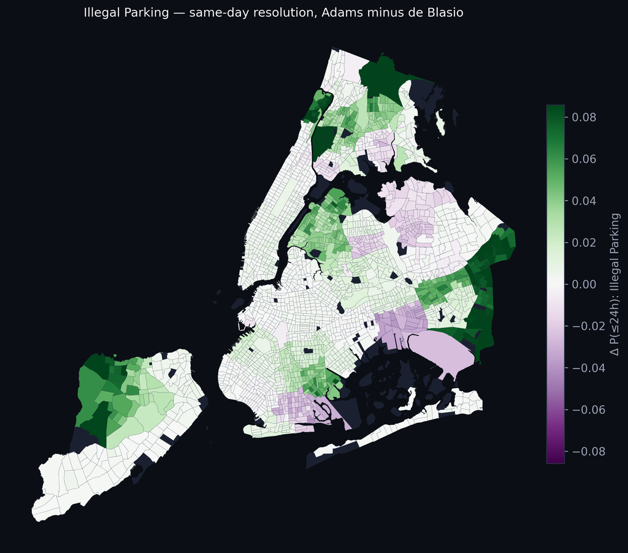

Figure 3: Tract-level change in same-day resolution probability, Adams era minus de Blasio (pre-COVID) era, for the mapped complaint type. Green = faster under Adams; purple = slower. Gray tracts lack 30+ requests in both eras.

```python
from matplotlib.collections import PolyCollection
from matplotlib.colors import TwoSlopeNorm

t_map = max(D_ad, key=lambda t: D_ad[t]["n"])       # best-covered type
dm = {g: d for g, d, _ in D_ad[t_map]["recs"]}
gj = json.load(open(os.path.join(ROOT, "web", "data", "tracts.geojson")))
polys, vals = [], []
for f in gj["features"]:
    geom, g = f["geometry"], f["properties"]["geoid"]
    rings = [geom["coordinates"][0]] if geom["type"] == "Polygon" \
        else [p[0] for p in geom["coordinates"]]
    for r in rings:
        polys.append(r); vals.append(dm.get(g, np.nan))
vals = np.array(vals, dtype=float)
vmax = max(np.nanpercentile(np.abs(vals), 95), .02)
fig, ax = plt.subplots(figsize=(9, 8.5))
ax.add_collection(PolyCollection([p for p, v in zip(polys, vals) if np.isnan(v)],
                                 facecolor="#1A2030", edgecolor=C["line"], linewidth=.1))
pc = PolyCollection([p for p, v in zip(polys, vals) if not np.isnan(v)],
                    array=vals[~np.isnan(vals)], cmap="PRGn",
                    norm=TwoSlopeNorm(vcenter=0, vmin=-vmax, vmax=vmax),
                    edgecolor=C["line"], linewidth=.1)
ax.add_collection(pc); ax.autoscale(); ax.set_aspect(1.3); ax.axis("off")
cb = fig.colorbar(pc, ax=ax, shrink=.6, pad=.01)
cb.set_label(f"Δ P(≤24h): {t_map.title()}", color=C["sub"])
cb.ax.yaxis.set_tick_params(color=C["sub"])
ax.set_title(f"{t_map.title()} — same-day resolution, Adams minus de Blasio",
             fontsize=12, color=C["text"])
plt.tight_layout(); plt.show()
```

**Mamdani administration vs Adams (provisional)**

```python
delta_table(D_ca) if D_ca else "Too little 2026 data yet for tract-level comparison."
```

Table 2: Mamdani vs Adams — provisional: 2026 has fewer months of matured data than the other eras and lacks the autumn and early-winter months.

|  | tracts compared | median Δ (pts) | 10th–90th pct | share sig. faster | share sig. slower |
| --- | --- | --- | --- | --- | --- |
| Elevator | 153 | 11.1 | +5 … +21 | 79% | 0% |
| Damaged Tree | 216 | 4.3 | -4 … +11 | 25% | 2% |
| Water System | 384 | 2.2 | -10 … +14 | 18% | 10% |
| General Construction/Plumbing | 86 | 1.1 | -8 … +11 | 13% | 10% |
| Maintenance Or Facility | 170 | 0.9 | -7 … +6 | 16% | 14% |
| Sidewalk Condition | 34 | 0.8 | -3 … +4 | 3% | 3% |
| Building/Use | 51 | 0.7 | -4 … +7 | 18% | 4% |
| Noise - Vehicle | 193 | -0.0 | -0 … +1 | 8% | 2% |
| Non-Emergency Police Matter | 56 | -0.0 | -1 … +1 | 2% | 0% |
| Noise - Residential | 1605 | -0.0 | -1 … +1 | 11% | 6% |
| Illegal Parking | 2106 | -0.0 | -1 … +2 | 22% | 11% |
| Noise - Commercial | 317 | -0.0 | -0 … +0 | 7% | 0% |
| Noise - Street/Sidewalk | 826 | -0.0 | -1 … +0 | 8% | 5% |
| Blocked Driveway | 1358 | -0.0 | -1 … +2 | 22% | 8% |
| Electric | 215 | -0.6 | -5 … +4 | 6% | 14% |
| Plumbing | 531 | -0.7 | -5 … +5 | 9% | 17% |
| Appliance | 132 | -0.7 | -2 … +1 | 2% | 8% |
| Unsanitary Condition | 761 | -0.9 | -2 … +1 | 1% | 26% |
| Derelict Vehicles | 96 | -1.0 | -20 … +12 | 18% | 24% |
| Paint/Plaster | 388 | -1.9 | -4 … +1 | 1% | 35% |
| Traffic Signal Condition | 331 | -2.1 | -11 … +6 | 5% | 18% |
| Noise | 327 | -3.3 | -14 … +9 | 9% | 27% |
| Overgrown Tree/Branches | 44 | -3.8 | -12 … +2 | 0% | 36% |
| Heat/Hot Water | 1198 | -4.7 | -12 … +5 | 7% | 41% |
| Sewer | 73 | -4.9 | -15 … +13 | 16% | 22% |
| Street Light Condition | 70 | -8.0 | -12 … -5 | 0% | 91% |
| Street Condition | 582 | -9.5 | -22 … +3 | 3% | 50% |

## Interpretation

*(This section is written against the rendered numbers above; the inline values update automatically on re-render.)*

**Values referenced in the prose**

```python
p24 = lambda k, t=None: (era_type_p24.loc[k, t] if t
                         else raw_all.loc[k])
noise_types = [t for t in TYPES if "Noise" in t]
noise_share = {k: df[df["era"] == k]["complaint_type"].isin(noise_types).mean()
               for k in era_keys}
raw_gain = raw_all.loc["adams"] - raw_all.loc["bloomberg"]
adj_gain = adj_all.loc["adams"] - adj_all.loc["bloomberg"]
covid_noise = noise_share.get("covid", float("nan"))
```

## Caveats, stated plainly

- **Recorded ≠ experienced.** Closure timestamps are administrative events. Era differences partly reflect record-keeping practice; batch-closure and never-closed rates are quantified in the era context table.
- **Bloomberg = final term only.** The public dataset begins 2010; nothing here speaks to 2002–2009.
- **Geocoding improves over time** (86% of 2010 requests are tract-mappable vs ~98% today), so early-era tract comparisons rest on a slightly thinner, possibly non-random subset of requests.
- **Taxonomy drift is handled conservatively**: only unambiguous renames are merged, and analysis is restricted to types present in every era. Types born after 2014 (e.g., outdoor dining complaints) are simply out of scope for the long arc.
- **Administrations are periods, not causes.** Nothing here identifies *why* a probability moved — budgets, laws, weather, and reporting behavior all changed concurrently. This is a descriptive account of associations within fixed geography.

## Technical addendum: modeling decisions, sensitivity, and robustness

This appendix records the decisions behind the machinery this analysis reuses, and the checks run along the way. Numbers quoted from prior evaluations are the documented outputs of the pipeline’s own harnesses (`docs/evaluation_results.md`, `docs/statistical_review.md`); everything specific to *this* document is computed in the chunks above.

### Model class

The estimator throughout is a hierarchical Dirichlet–Multinomial over the nine ordered duration bins, with partial pooling tract → NTA → borough → citywide, fit as a top-down conjugate cascade (each node’s Dirichlet prior is κ pseudo-counts shaped like its parent’s posterior mean). It is fitted once per cumulative threshold: the bins are merged into “within X” versus “later” (a Dirichlet merged over categories is a Dirichlet with summed parameters) and each of the eight two-category hierarchies has its own pooling strengths, so the rates being compared are not over-smoothed by strengths dominated by other bins. The eight cumulative curves are made non-decreasing with a running maximum. The era fits in this report use the same model as the live map. Alternatives considered and rejected: continuous-time survival models (non-conjugate inference at 40M rows for a deliverable that is the binned distribution anyway); continuation-ratio Beta–Binomial stacks (equally conjugate but no actual adjacent-bin smoothing without breaking conjugacy — bin order is instead respected at evaluation time via the ranked probability score); and full hierarchical Bayes with sampled concentrations (too slow for a weekly refresh of every cell). The plug-in shortcut was then checked against a fully Bayesian Stan fit for one borough and three complaint types: tract means differ by 0.7–1.1 points on average (`docs/stan_validation.md`). Pooling runs within complaint type across geography, not across types within a tract, because resolution speed is owned by the responsible agency, not the neighborhood.

### Configuration contest (live map)

Ten configurations were compared on a temporal holdout (train 2024-08 → 2025-08, test the following 12 months; all hyperparameters fit on train only), scored by mean RPS (primary), log-loss, calibration error, and interval calibration, with paired block-bootstrap SEs over tract×type cells (`docs/evaluation_results.md`):

| configuration | RPS | vs. best |
| --- | --- | --- |
| No pooling (uniform / Jeffreys) | 0.10685 / 0.10548 | +0.00395 / +0.00258 |
| Hierarchy, fixed κ=15 | 0.10365 | +0.00075 |
| Hierarchy, EB κ (per type / per type-level) | 0.10316 / 0.10318 | +0.00026 / +0.00028 |
| + 90-day decay (previous model) | 0.10302 | +0.00012 |
| + 180-day / 365-day decay | 0.10290 / 0.10297 | best / +0.00007 |
| **+ per-threshold pooling, 90-day decay (shipped)** | **0.10297** | +0.00007 |

The no-pooling baselines’ failure mode is exact and diagnostic: on tract×type cells unseen in training they predict the bare prior — uniform over nine bins, log-loss log(9) = 2.197 — while the hierarchy falls back to the neighborhood estimate (1.73–1.88).

This single split trains once and predicts up to a year ahead, which favors long memory and is not how the map is used; the weekly-refit setting is tested by a rolling-origin evaluation that refits at each month start and scores only that month (`docs/rolling_evaluation.md`). There, half-lives of 45 to 180 days are statistically tied with the nine-bin 90-day model (differences of 0.00000 to +0.00004 RPS), 365 days is worse by 0.00014 ± 0.00005, and no decay by 0.00040 ± 0.00008, so 90 days stays. The shipped per-threshold model beats the nine-bin model with the same decay in that protocol by 0.00019 ± 0.00002 RPS and 0.00084 ± 0.00016 log-loss.

### Defects found by audit, all fixed

Adversarial computational audits (independent re-implementation of the cascade; verification of every exported cell against the raw files) found:

1. **Concentration estimation under-converged.** Minka’s fixed-point iteration stalled far short of the marginal-likelihood optimum on these flat surfaces (tract-level Heat/Hot Water: κ ≈ 230 vs true optimum ≈ 800, a 78-nat likelihood gap; Illegal Parking: 87 vs ≈ 400, 288 nats). The estimator now maximizes the exact Dirichlet–Multinomial marginal likelihood by bounded scalar optimization. Predictions moved negligibly (the flat surface is why the defect was silent), but pooling strengths are now genuine MLEs — including the era fits above.
2. **Raw posterior intervals badly under-covered.** In the original audit, coverage of nominal 90% intervals on dense cells was 0.25–0.51 — including on an even/odd day-of-year split where drift is impossible by construction, refuting an initial “temporal drift” explanation. The live map’s intervals now add a per-type, per-threshold regime variance estimated from rolling 60-day temporal holdouts; on the current data, coverage is 0.911 in dense cells and about 0.91 in sparse ones (squared standardized residual 1.05). A multiplicative (design-effect) correction was tested and rejected — it absurdly inflates sparse-cell intervals. The even/odd-day shortfall has since been tested directly (`docs/robustness_checks.md`): most of it is that the held-out half is itself a finite sample (coverage 0.69 against the true-rate interval, 0.89 once the half’s own noise is counted), and the rest is day-to-day clustering of outcomes within cells (dispersion 1.29; inflating the sampling variance by it gives 0.90). Batch closures are not the cause. Under the deployed protocol (regime variance re-estimated before each of 11 months, next month scored) overall coverage is 0.874 (`docs/interval_calibration_rolling.md`).
3. **Requests without a tract were counted in one tract.** Under pandas 2, converting the tract column with `astype(str)` turned missing values into the text “nan”, so about 1.6% of requests were counted in Rikers Island (tract 36005000100); pandas 3 keeps them missing, so the result depended on the installed version. Fixed, verified across versions, and guarded by export checks (`docs/statistical_review.md` §7). The era fits in this report were not affected: they load the data with their own null handling.
4. **Interval theory ignored the uncertainty of the borrowed neighborhood mean.** A simulation with known truth showed 43–81% coverage for nominal 90% intervals even when the data follow the model exactly; the interval variance now includes that term (`docs/simulation_check.md`). On real data the regime variance dominates, so users see almost no change.

### Sensitivity and robustness checks run

- **Decay half-life**: rolling-origin comparison over 11 monthly refits (see above); 45–180 days are tied, 365 days and no decay are worse.
- **Seasonal blending**: a same-season-last-year kernel (conjugate, weight β·2^(−|age−1yr|/bw)) was re-tested with two years of history under the same rolling protocol. The best variant improves RPS by 0.00013 ± 0.00004 and log-loss by 0.00176 ± 0.00038 but wins in only 5 of the 11 months, so it is not adopted (`pipeline/eval_rolling.py`).
- **Pooling strength per threshold**: fitting a separate strength for each cumulative threshold improves held-out log-loss at all eight thresholds (mixed by type, marginal for the all-complaints view) and lets the maps show the tract-level variation the data support; adopted for the live map and for the era fits here (`docs/cutwise_evaluation.md`). Switching the era fits to it moved the tract-level tables modestly (for example, the share of Heat/Hot Water tracts with a credible increase under Adams versus de Blasio fell from 95% to 87%), because less pooling means less of each tract’s change is shared with its neighborhood.
- **Censoring**: the 31-day maturity cutoff is keyed to the top bin boundary, making the “still open ⇒ month+” assignment deductively exact rather than imputed; verified against pull dates. Composition of the month+ bin was audited on the original window: 8.8% of matured requests land there, 28.5% of those never close; for Heat/Hot Water >99% of month+ cases are administrative non-closures — reported as-is with a high-open-share flag.
- **Cleaning funnel** (current live window): 7.52M → 7.08M rows; about 286k double-submissions collapsed, 131k exact-zero durations dropped, 114k batch closures flagged and *kept*. Re-running the rolling evaluation and the map fit without them (`docs/robustness_checks.md`) moved the all-complaints citywide 24-hour figure from 58.6% to 59.9% and borough-by-type figures by at most 2.1 points, improved predictions for unflagged requests negligibly and worsened predictions for all requests; their per-era rates are also disclosed in the era context table.
- **Independent audit** (`pipeline/audit.py`): raw rows reconcile with the funnel; every tract × type count matches an independent tally; binning is correct at the bin boundaries; a separate re-implementation of the per-threshold hierarchies reproduces all 51,150 cells; and one month recomputed from the raw files agrees with the pipeline to 0.1 point.
- **RPS implementation** verified against hand computation; bootstrap resamples cells, not requests (within-cell correlation would otherwise understate SEs).

### Choices specific to this historical analysis

- **Era fits use no decay**: the estimand is each era’s average recorded behavior, not a nowcast. Concentrations are re-estimated per era, so pooling strength adapts to each era’s data density.
- **Stable-type restriction** (≥15k requests in every era) plus conservative 1:1 rename normalization; types that split or merged across the 2014 taxonomy overhaul are excluded rather than guessed at.
- **Tract deltas require n ≥ 30 in both eras** so differences reflect local evidence rather than two shared priors agreeing with each other; interval on the delta is the normal combination of the two independent Beta variances. This intentionally reports *sampling* uncertainty for a fixed-era estimand — the regime-variance component the live map adds is a forecasting correction and would be wrong here.
- **Composition adjustment** fixes the complaint mix at the pooled all-era distribution; the raw-vs-adjusted gap isolates how much of each era’s apparent speed is reporting mix.
- **COVID quarantine** (2020-03 – 2021-12) keeps an extraordinary operating regime out of both adjacent administrations’ records.
- **Known residual risks**: geocoding coverage drift (86% → 98% tract-mappable); recorded-vs-experienced resolution; single-observation seasonality in the partial-year Mamdani era (2026), which lacks autumn and early winter.

### Reproduction

```
python3 pipeline/fetch_311.py            # rolling two-year window
python3 pipeline/fetch_311_history.py    # 2010-2024 archive (~38M rows)
python3 pipeline/prepare.py && python3 pipeline/prepare_hist.py --all
quarto render docs/historical_analysis.qmd
```

Full detail: `docs/model_spec.md` (specification), `docs/evaluation_results.md` and `docs/rolling_evaluation.md` (evaluation), `docs/statistical_review.md` (audits), `docs/METHODS.md` (public methods).

*Data: NYC Open Data — 311 Service Requests (2010–2019 archive `76ig-c548`; 2020–present `erm2-nwe9`). Cleaning and model code: `pipeline/` in this repository. Not affiliated with the City of New York.*